# ANVIDEA - Reporte reproducible

Capítulo 6 — Patrones de distribución y estimación de la densidad

Autor/a

Javier Rodríguez-Barrios

Fecha de publicación

18 de abril de 2026

# Presentación

Este reporte corresponde al **Capítulo 6 — Patrones de distribución y estimación de la densidad** del proyecto **ANVIDEA**. Su propósito es articular los casos guiados con los scripts del repositorio, ofreciendo tablas, figuras e interpretaciones ecológicas para estudiantes que ejecutan el capítulo completo con `source("run_cap6.R")`.

**Lo que desarrolla este capítulo**

1. **Evaluar el patrón espacial** de una población vegetal mediante ajuste a distribuciones probabilísticas e índices de dispersión.
2. **Comparar Poisson y Binomial Negativa** como modelos alternativos para describir la distribución de conteos por unidad muestral.
3. **Estimar la densidad poblacional** mediante métodos basados en distancias: Holgate, King y Hayne.

# Caso A. Patrones de distribución espacial

## Contexto ecológico

Cuando se estudia una población en campo, una de las primeras preguntas ecológicas es: **¿cómo están distribuidos los individuos en el espacio?** Los individuos pueden estar dispersos de forma aleatoria, agregada o uniforme, y cada patrón tiene implicaciones distintas sobre la competencia, la facilitación, el acceso a recursos y la historia natural de la especie.

Para responder esta pregunta se registran los **conteos por unidad muestral** (cuadrículas, parcelas, puntos) y se compara la distribución observada con la esperada bajo distintos modelos probabilísticos.

## Paso 1. Descripción de la muestra

La muestra cuenta con **48 unidades de muestreo** y **26 individuos** en total. La media es 0.54 y la varianza es 1.15. Cuando la varianza supera notablemente a la media, ello anticipa un posible patrón **agregado**.

Tabla 1: Estimadores descriptivos de la muestra evaluada

| n (cuadriculas) | N (individuos) | media | varianza |
| --- | --- | --- | --- |
| 48 | 26 | 0.54 | 1.15 |

## Paso 2. Ajuste a la distribución de Poisson

La distribución de **Poisson** describe el número de eventos aleatorios en una unidad de espacio o tiempo. Si la población se distribuye al azar, los conteos por cuadrícula deberían seguir esta distribución con parámetro $\lambda = \mu$.

### Frecuencias observadas vs. esperadas

Tabla 2: Frecuencias, Poisson esperada y chi^2

| x | Fx | Px | Ex | chi^2 comp |
| --- | --- | --- | --- | --- |
| 0 | 33 | 0.58 | 27.9 | 0.92 |
| 1 | 11 | 0.32 | 15.1 | 1.13 |
| 2 | 0 | 0.09 | 4.1 | 4.10 |
| 3 | 1 | 0.02 | 0.7 | 0.09 |
| 4 | 3 | 0.00 | 0.1 | 83.95 |

### Agrupación y prueba de bondad de ajuste

Para garantizar la validez de la prueba $\chi^2$, las clases con frecuencias esperadas bajas se agrupan. Los grados de libertad se calculan como $k - 1 - 1$, descontando el parámetro estimado ($\mu$).

Tabla 3: Frecuencias agrupadas (3 clases: 0, 1, ≥2)

| clase | Fx | Ex | chi^2 comp |
| --- | --- | --- | --- |
| 0 | 33 | 27.93 | 0.92 |
| 1 | 11 | 15.13 | 1.13 |
| ≥2 | 4 | 4.94 | 0.18 |

Tabla 4: Prueba de bondad de ajuste chi^2 — Poisson

| chi^2 (baj) | gl | p-valor |
| --- | --- | --- |
| 2.23 | 1 | 0.136 |

Un p-valor **pequeño** (< 0.05) indica que los datos se alejan significativamente de una distribución aleatoria.

### Figura: observado vs. Poisson esperado

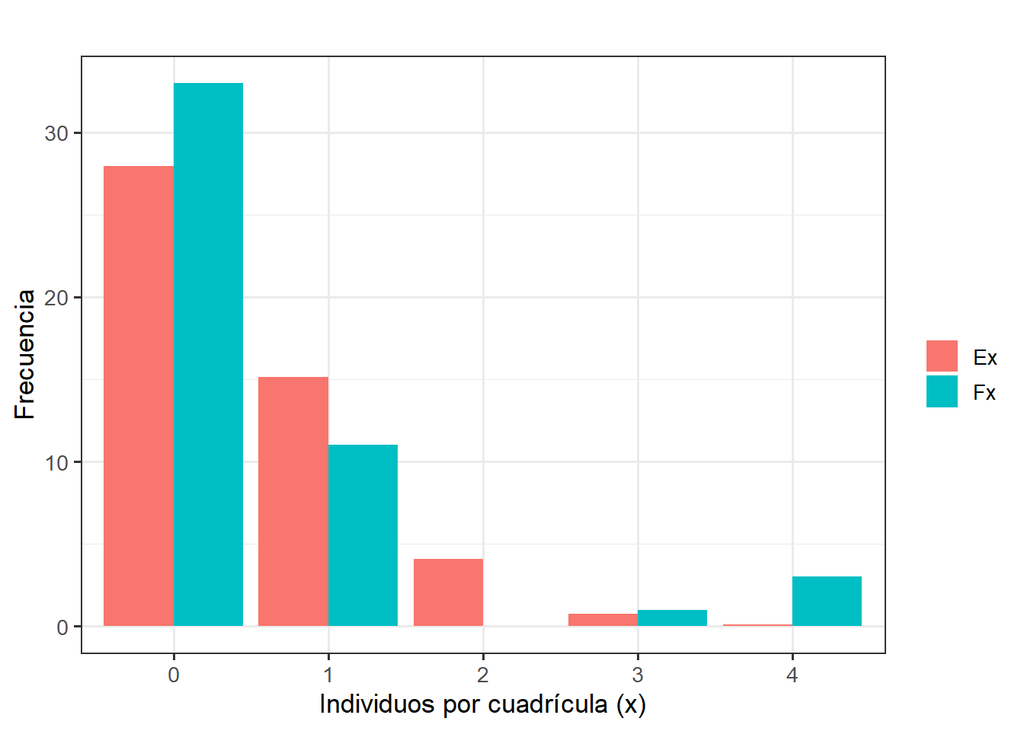

Figura 1: Distribución de frecuencias observadas vs. esperadas (Poisson)

### Índice de Morisita

Tabla 5: Índice de Morisita para el patrón espacial

| I_M (Morisita) | Interpretacion |
| --- | --- |
| 3.102 | Agrupado |

## Paso 3. Ajuste a la Binomial Negativa

La **Binomial Negativa** incorpora un parámetro de agregación $k$ que permite modelar poblaciones con tendencia a concentrarse en ciertas unidades. Valores pequeños de $k$ indican mayor agregación.

### Estimación del parámetro k

Tabla 6: Estimador inicial de k (método de momentos)

| k (momentos) |
| --- |
| 0.485 |

### Frecuencias observadas vs. BN esperadas

Tabla 7: Frecuencias observadas, BN esperada y chi^2

| x | Fx | Px | Ex | chi^2 comp |
| --- | --- | --- | --- | --- |
| 0 | 33 | 0.695 | 33.368 | 0.004 |
| 1 | 11 | 0.178 | 8.534 | 0.712 |
| 2 | 0 | 0.070 | 3.344 | 3.344 |
| 3 | 1 | 0.030 | 1.462 | 0.146 |
| 4 | 3 | 0.014 | 0.672 | 8.064 |

### Agrupación y bondad de ajuste

Tabla 8: Frecuencias agrupadas (4 clases: 0, 1, 2, ≥3) — BN

| clase | Fx | Ex | chi^2 comp |
| --- | --- | --- | --- |
| 0 | 33 | 33.368 | 0.004 |
| 1 | 11 | 8.534 | 0.712 |
| 2 | 0 | 3.344 | 3.344 |
| ≥3 | 4 | 2.134 | 1.632 |

Tabla 9: Prueba de bondad de ajuste chi^2 — Binomial Negativa

| chi^2 (baj BN) | gl (BN) | p-valor (BN) |
| --- | --- | --- |
| 5.693 | 3 | 0.128 |

### Figura: observado vs. BN esperado

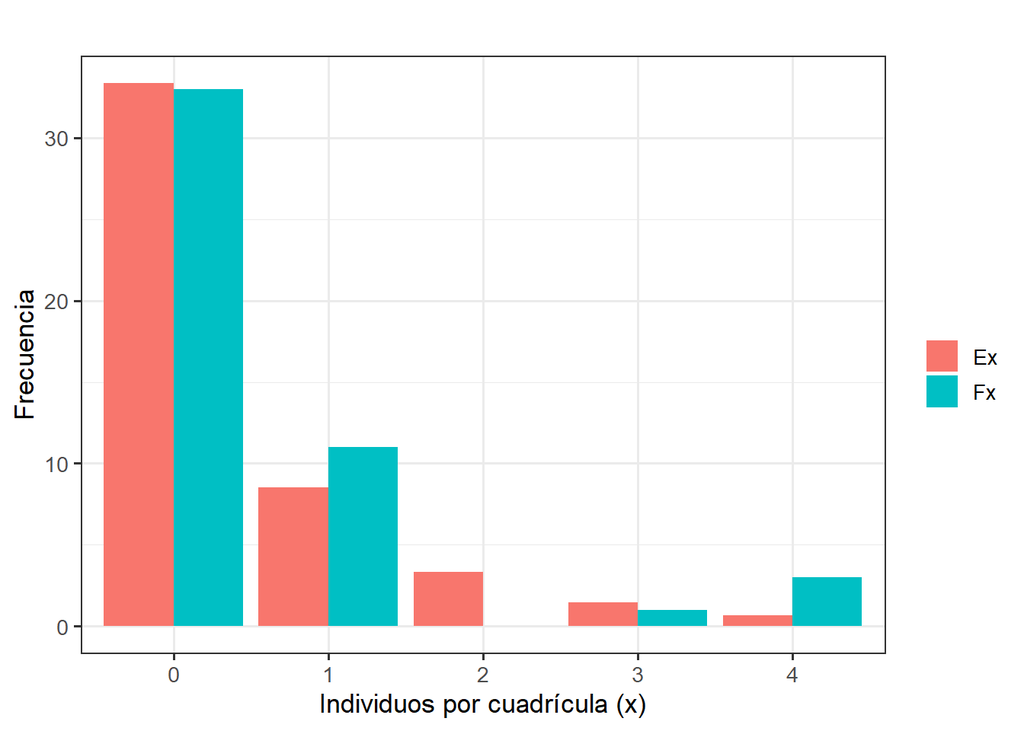

Figura 2: Distribución de frecuencias observadas vs. esperadas (Binomial Negativa)

## Paso 4. Comparación de modelos: Poisson vs. Binomial Negativa

El criterio de información de Akaike (AIC) permite comparar los dos modelos de forma objetiva. El modelo con menor AIC y mayor peso $w_{AIC}$ representa mejor los datos observados.

Tabla 10: Comparación de modelos por AIC (MLE)

| Modelo | logLik | k | AIC | Delta_AIC | wAIC |
| --- | --- | --- | --- | --- | --- |
| Poisson (glm) | -53.267 | 1 | 108.533 | 9.944 | 0.007 |
| Binomial Negativa (glm.nb) | -47.295 | 2 | 98.589 | 0.000 | 0.993 |

## Paso 5. Índices de dispersión

Los índices de dispersión permiten sintetizar el patrón espacial sin depender de un ajuste de distribución. Se calculan a partir de la relación entre varianza y media.

Tabla 11: Diagnósticos de patron espacial

| ID = s2/mu | IC (D. & M.) | IH (Holgate) | Lloyd m* | Ic (Lloyd) | Morisita IM | chi2_disp | gl | p |
| --- | --- | --- | --- | --- | --- | --- | --- | --- |
| 2.12 | 1.12 | NA | 1.66 | 3.06 | 3.1 | 99.54 | 47 | 1e-05 |

Un **ID > 1** indica agregación; **ID ≈ 1** aleatoriedad; **ID < 1** uniformidad. El Índice de Morisita y el de Lloyd confirman o matizan esta conclusión.

# Caso B. Estimación de la densidad

## Contexto ecológico

Cuando no es posible censar directamente toda la población, la densidad se estima a partir de **distancias** entre puntos de muestreo e individuos. Los métodos de Holgate, King y Hayne son tres estimadores clásicos que difieren en cómo resumen esas distancias y en sus supuestos sobre la distribución espacial.

## 1. Método de Holgate

Holgate estima la densidad usando la **distancia cuadrática** $x^2$ desde puntos aleatorios al individuo más cercano. La fórmula es:

$$D_{Ht} = \frac{n}{\pi \sum x^2_i}$$

Tabla 12: Vista previa — Densidad por puntos de interseccion al azar

| Punto de intersección | Indv_1_cm | Indv_2_cm | Indv_1_m | Indv_2_m | x2_m |
| --- | --- | --- | --- | --- | --- |
| 1 | 250 | 290 | 2.50 | 2.90 | 6.250 |
| 2 | 370 | 500 | 3.70 | 5.00 | 13.690 |
| 3 | 208 | 300 | 2.08 | 3.00 | 4.326 |
| 4 | 27 | 32 | 0.27 | 0.32 | 0.073 |

Tabla 13: Holgate — Densidad estimada

| n_puntos | sum_x2_m2 | D_Ht_m2 | D_Ht_ha |
| --- | --- | --- | --- |
| 58 | 383.504 | 0.04814 | 481 |

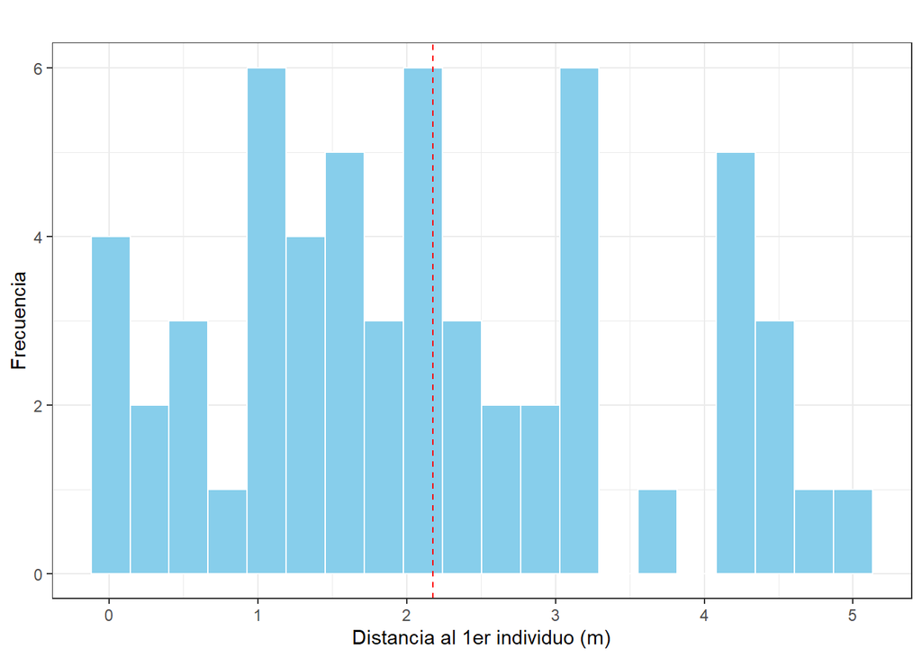

Figura 3: Distribucion de distancias usadas en el metodo de Holgate

## 2. Métodos de King y Hayne

King y Hayne se aplican sobre puntos distribuidos en un **transecto diagonal**. Comparten los datos de distancias pero difieren en la fórmula de estimación:

- **King**: $D_K = \frac{n^2}{2 \cdot L \cdot \sum d_i}$
- **Hayne**: $D_H = \frac{\sum (1/d_i)}{2 \cdot L}$

Tabla 14: Vista previa — Densidad por transecto diagonal

| Individuo | di_m | 1/di |
| --- | --- | --- |
| 1 | 0.23 | 4.348 |
| 2 | 0.00 | 0.000 |
| 3 | 0.17 | 5.882 |
| 4 | 0.15 | 6.667 |

Tabla 15: Indices de King y Hayne — Densidad estimada

| L (m) | n (puntos) | sum di (m) | sum 1/di | King (ind/m2) | King (ind/ha) | Hayne (ind/m2) | Hayne (ind/ha) |
| --- | --- | --- | --- | --- | --- | --- | --- |
| 28.28 | 20 | 23.74 | 36.82 | 0.298 | 2979 | 0.65 | 6509 |

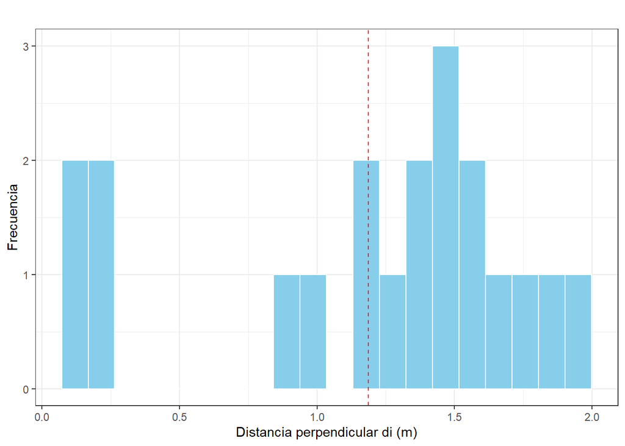

Figura 4: Distribucion de distancias di — metodo King

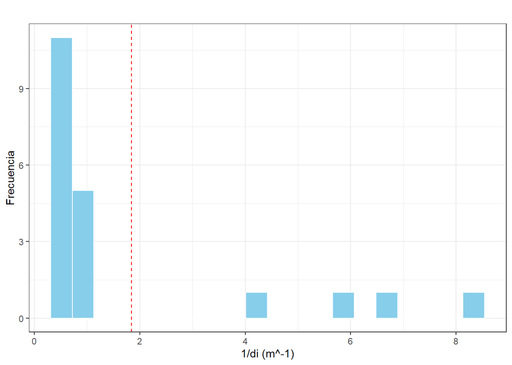

Figura 5: Distribucion de 1/di — metodo Hayne

# Integración final del capítulo

Los dos casos guiados abordan dimensiones complementarias de la ecología de poblaciones. El **patrón espacial** revela cómo los individuos ocupan el espacio — con implicaciones sobre competencia, facilitación y estructura del hábitat. La **densidad** cuantifica cuántos individuos hay por unidad de área, dato fundamental para el manejo y la conservación.

La comparación entre Holgate, King y Hayne ilustra que la densidad no es un valor absoluto sino una **estimación condicionada por el método**: cada fórmula resume la información de distancias de forma distinta y tiene sus propios supuestos. Evaluar la coherencia entre los tres métodos es parte del análisis.

En conjunto, este capítulo muestra que el análisis ecológico riguroso requiere integrar datos, modelos probabilísticos, índices descriptivos y representación gráfica — no una sola fórmula aislada.